# Итоговый проект: бот для рекомендации видеоигр из Steam

Группа 10

### **Идея**

Нашей целью было разработать рекомендательную систему видеоигр из Steam с двумя рабочими сценариями. Согласно первому из них, пользователь получал бы рекомендации на оценок личных оценок других игр. Согласно второму, рекомендация выводилась бы на запрос пользователя естественным языком, то есть, пользователь мог бы использовать собственные ассоциации и характеристики для описания желаемой игры вместо того, чтобы выбирать их из нескольких вариантов ответа, как зачастую бывает в рекомендательных системах.

Целевой аудиторией нашего проекта можно назвать как опытных, так и начинающих игроков, так как наши сценарии прекрасно подходят для обеих групп. Мы предполагаем, что первый сценарий окажется более востребован среди новичков, поскольку из-за малого опыта они могут плохо представлять себе игру своей мечты. А более опытные игроки наоборот могут знать уже слишком много игр, чтобы открыть для себя что-то новое просто с помощью контентно-ориентированной фильтрации, и рекомендация на основе их собственных характеристик может помочь им в этом. Однако в целом, подобная логика является достаточно субъективной и условной, и в реальности вполне может оказаться, что второй сценарий будет популярен среди аудитории с малым игровым опытом, а первый - среди опытных геймеров.

**Тип проекта:** рекомендательный

**Данные:** Мы использовали данные с Kaggle, конкретно – датасет Steam Games Complete Dataset с наименованиями более 40 тысяч игр из магазина цифровых товаров Steam (https://www.kaggle.com/trolukovich/steam-games-complete-dataset). Для построения системы рекомендация нам нужны были колонки url, name, popular_tags, genre и game_description.

### **Распределение ролей**

1. Бреславский Александр: создание бота в телеграм, работа с сервером
2. Вахрушева Татьяна: база данных, работа с сервером
3. Гильмутдинова Алина: создание рекомендательной системы, хранение данных, создание бота в телеграм
4. Мигунов Юрий: менеджмент, создание рекомендательной системы
5. Писковский Роман: менеджмент, создание рекомендательной системы

### **Предобработка**

Так как Steam распространяет не только видеоигры, мы отчистили датасет от цифровых саундтреков, обоев, приложений-редакторов видео/фото, а также других не игровых товаров.

Для двух используемых в боте сценариев была выполнена и индивидуальная обработка. Для первого данные о тегах и жанрах были преобразованные в бинарный формат, а для сценария с текстовым запросом все возможные текстовые описания для каждой из игр были объединены для дальнейшего поиска схожести.

### **Методы машинного обучения**

В качестве основного метода машинного обучения в нашем проекте использовался кластеринг.

Во втором сценарии, пользовательских запрос преобразуется в токены и проходит кластеризацию вместе со всем датасетом для сужения списка дальнейшего поиска схожести между играми.

Таким образом была решена задача более точного определения категории игры, которую может желать увидеть пользователь.

### **Архитектура приложения**

Модели рекомендации каждого из сценаривев строятся в приложении. Когда пользователь начинает работу с ботом, мы сохраняем его уникальный id и в дальнейшем используем его для формирования индивидуальной рекомендации. При пользовательской оценке игр в первом сценарии и при вводе текстового описания во втором сценарии пользователями, мы также сохраняем и используем эти входные данные для активирования функция по созданию рекомендации. Для каждого нового ввода строится новая модель. Мы используем заранее подготовленные датасеты с названиями игр для оценки в первом сценарии.

Расскажем немного подробнее о работе сценариев. В первом сценарии оценка пользователя придает тегам игры вес: оценка “5” значит, что вес тегов этой игры внутри системы умножается на 2, “4” - на 1.5, “3” - на 1, “2” - на 0.75 и “1” - на 0.5. В результате вес тэгов игр суммируется, и игры с итоговым максимальном весом тэгов таким образом определяются как самые подходящие для пользователя. Если какая-либо рекомендация не устраивает человека, то она убирается из списка, а вместо нее предлагается следующая по сумме весов игра. В списке рекомендаций для каждого пользователя мы оставляем 70 игр, поэтому заменять неугодные игры можно хоть и не бесконечно, но достаточно долго.

Во втором сценарии, пользовательский запрос преобразуется в токены и проходит кластеризацию вместе со всем датасетом для выделения кластеров схожих по описаниям игр, путем поиска совпадающих слов в тегах игр и пользовательском запросе. Таким образом список для дальнейшего поиска схожести между играми сужается, благодаря чему точность рекомендации выше. Таким способом была решена задача более точного определения категории игры, которую может желать увидеть пользователь.

Изначально мы планировали, что наше приложение будет сохранять данные (id пользователя, юзернейм, рекомендация системы, состояние пользователя и его фидбек) в базе данных. Но поскольку БД работала несколько некорректно (приложение ломалось при прогоне соответствующих строк кода), то было решено хранить те же данные в csv-таблицах recommendations, users и feedbacks. В долгосрочной перспективе эти данные мы сможем использовать для выявления недостатков внутри системы рекомендаций и дальнейшего улучшения эффективности приложения.

### **Интерфейс**

Наш бот работает следующим образом: После команды /start и краткого знакомства с ботом пользователь должен выбрать, с каким сценарием он хотел бы работать.

**Входные данные:** команда /start

**Выходные данные:** приветствие пользователя и инструкция по пользованию ботом

**Скрин интерфейса:**

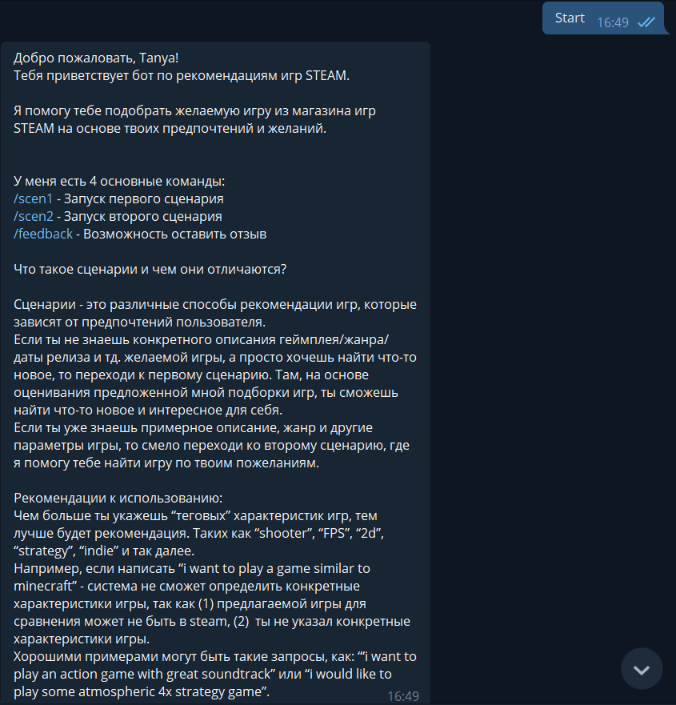

**Код интерфейса:**

```r
username <- update$message$from$first_name

    bot$sendMessage(update$message$chat_id,
                  text = paste0("Добро пожаловать, ", username, "!
Тебя приветствует бот по рекомендациям игр STEAM.

Я помогу тебе подобрать желаемую игру из магазина игр STEAM на основе твоих предпочтений и желаний.


У меня есть 4 основные команды:
/scen1 - Запуск первого сценария
/scen2 - Запуск второго сценария
/feedback - Возможность оставить отзыв

Что такое сценарии и чем они отличаются?

Сценарии - это различные способы рекомендации игр, которые зависят от предпочтений пользователя.
Если ты не знаешь конкретного описания геймплея/жанра/даты релиза и тд. желаемой игры, а просто хочешь найти что-то новое, то переходи к первому сценарию. Там, на основе оценивания предложенной мной подборки игр, ты сможешь найти что-то новое и интересное для себя.
Если ты уже знаешь примерное описание, жанр и другие параметры игры, то смело переходи ко второму сценарию, где я помогу тебе найти игру по твоим пожеланиям.

Рекомендации к использованию:
Чем больше ты укажешь “теговых” характеристик игр, тем лучше будет рекомендация. Таких как “shooter”, “FPS”, “2d”, “strategy”, “indie” и так далее.
Например, если написать “i want to play a game similar to minecraft” - система не сможет определить конкретные характеристики игры, так как (1) предлагаемой игры для сравнения может не быть в steam, (2)  ты не указал конкретные характеристики игры.
Хорошими примерами могут быть такие запросы, как: “‘i want to play an action game with great soundtrack” или “i would like to play some atmospheric 4x strategy game”."),
                  parse_mode = "Markdown")
```

*Сценарий 1:*

Если пользователь выбрал первый сценарий (команда /scen1), то он получает небольшое уведомление о шкале оценок и предложение оценить первую игру из списка.

**Входные данные:** команда /scen1

**Выходные данные:** краткая инструкция по расставлению пользовательских оценок и по работе со сценарием, выдача названия первой игры для оценки

**Скрин интерфейса:**

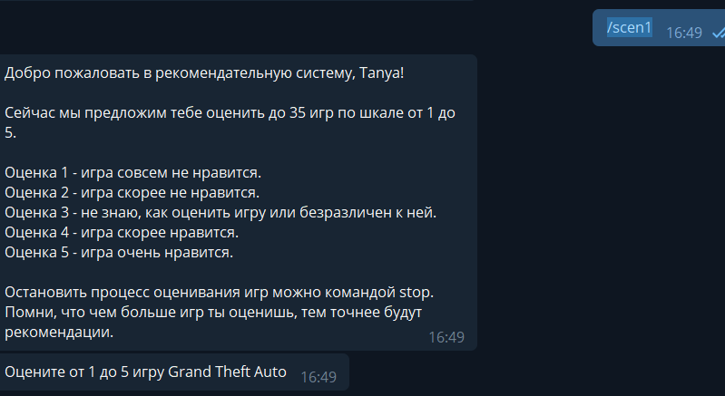

**Код интерфейса:**

```r
# здесь код только для интерфейса
bot$sendMessage(update$message$chat_id,
                text = paste0("Добро пожаловать в рекомендательную систему, ", username , "!\n\nСейчас мы предложим тебе оценить до 35 игр по шкале от 1 до 5.\n\nОценка 1 - игра совсем не нравится.\nОценка 2 - игра скорее не нравится.\nОценка 3 - не знаю, как оценить игру или безразличен к ней.\nОценка 4 - игра скорее нравится.\nОценка 5 - игра очень нравится.\n\nОстановить процесс оценивания игр можно командой stop. Помни, что чем больше игр ты оценишь, тем точнее будут рекомендации."),
                  parse_mode = "Markdown")

  # Отправляем сообщение с просьбой оценить первую игру
  bot$sendMessage(update$message$chat_id,
                    text = paste0("Оцените от 1 до 5 игру ", rownames(ratings)[1]),
                  parse_mode = "Markdown")
```

Затем пользователь оценивает предлагаемые игры либо до конца нашего списка из 35 позиций, либо до того как ему надоест.

**Входные данные:** оценка в числовой форме

**Выходные данные:** выдача названия следующей игры из списка для оценивания игр. таким образом особо упорный пользователь либо проставляет все 35 оценок, либо пишет команду /stop.

**Скрин интерфейса:**

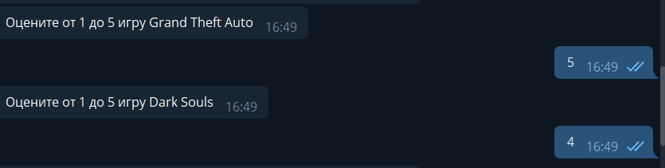

**Код интерфейса:**

```r
# здесь код только для интерфейса
 # Отправляем сообщение с просьбой оценить первую игру
  bot$sendMessage(update$message$chat_id,
                    text = paste0("Оцените от 1 до 5 игру ", rownames(ratings)[1]),
                    parse_mode = "Markdown")
```

После этого пользователь получает рекомендацию, которая содержит название игры и ссылку на неё в Steam, чтобы пользователь мог ознакомиться с игрой непосредственно в маркете.

**Входные данные:** оценка последней 35й игры в числовой форме или команда /stop

**Выходные данные:** рекомендация на основе проставленных оценок

**Скрин интерфейса:**

[figure not shown]

```r
# здесь код только для интерфейса
send_table <- function( bot, update, table ) {
  message <- "Ваши рекомендации:\n\n"
  for(i in 1:(nrow(table))){
    message <- paste0(message, i, ". ")
    message <- paste0(message, as.character(table[i, 1]), "\n", as.character(table[i, 2]), "\n\n")
  }
  bot$sendMessage(update$message$chat_id, text = message)
}
```

*Сценарий 2:*

Для работы второго сценария пользователь вводит /scen2.

**Входные данные:** команда /scen2

**Выходные данные:** приветствие и указание по работе со сценарием

**Скрин интерфейса:**

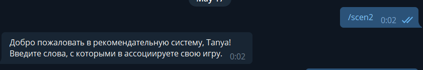

```r
# Отправляем приветсвенное сообщение
bot$sendMessage(update$message$chat_id,
                text = paste0("Добро пожаловать в рекомендательную систему, ", username , "!\nВведите слова, с которыми в ассоциируете свою игру."),
                  parse_mode = "Markdown")
}
```

После ввода запроса пользователь ожидает примерно 1-2 минуты и получает 5 рекомендованных игр, как и в первом сценарии, с ссылками в Steam

**Входные данные:** слова-ассоциацие с желаемой игрой

**Выходные данные:** уведомление о подготовке рекомендации и сама рекомендация непосредственно (через какое-то время)

**Скрин интерфейса:**

[figure not shown]

```r
  # Если пользователь получает рекомендации по ВТОРОМУ сценарию (имеет состояние "recommendation_second_scenario") С помощью рекомендательной системы по описанию пользователя формируется топ 70 игр, которые ему рекомендуются. Эти игры записываются в датафрейм recommendations и отправляются сообщением пользователю.
  if(user_state == "recommendation_second_scenario") {
    # Достаём текст сообщения
    message_text <- update$message$text
    # Удаляем пробелы в начале и в конце сообщения
    message_text <- trimws(message_text, which = "b")
    # Создание рекомендаций идёт долго, поэтому отправляем пользователю сообщение с предупреждением
    bot$sendMessage(update$message$chat_id,
                  text = paste0("Создание рекомендаций по описанию занимает некоторое время. Пожалуйста, подождите..."),
                  parse_mode = "Markdown")
    # Создаём рекомендации
    second_scenarion_recommendations(user_id, message_text)
    # Получаем рекомедации пользователя после их создания
    user_recommendations <- recommendations[recommendations$user_id == user_id, ] %>% head(5) %>% select("name", "url")
```

Также есть опция отзыва о полученной рекомендации. Она необязательна, но для дальнейшей работы над системой оказывает неоценимую пользу!

**Входные данные:** команда /feedback и отзыв о рекомендации

**Выходные данные:** благодарность за отзыв :)

**Скрин интерфейса:**

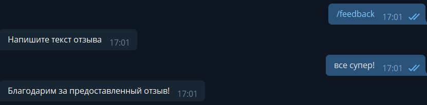

```r
bot$sendMessage(update$message$chat_id,
                  text = paste0("Напишите текст отзыва"),
                  parse_mode = "Markdown")

bot$sendMessage(update$message$chat_id,
                text = "Благодарим за предоставленный отзыв!",
                parse_mode = "Markdown")
```

Для обоих сценариев у нас также есть опция замены рекомендации. Так, если пользователю не нравится какая-либо рекомендованная игра, он может просто написать её номер в списке, и тогда он получит обновленный список из 5 игр.

### **Оценивание / Выводы**

Сначала мы проводили формальное тестирование приложения на адекватность рекомендации среди команды разработчиков. После того, как каждый из нас остался доволен полученными рекомендациями и оценивал систему как эффективную, мы предлагали нашим друзьям и знакомым воспользоваться приложением, чтобы главным образом оценить качество рекомендаций, а также понятность, простоту и удобство интерфейса. В итоге, примерно в 80% всех случаев пользователи оставались довольны полученными рекомендациями, а к интерфейсу у экспериментаторов вопросов не возникало. В целом, это можно назвать очень хорошим результатом.

### **Ссылка на приложение**

https://drive.google.com/drive/folders/1QSq6AfjI-v6xmf_AWiUDOmkZIIDBnHn3

### **Ответы на вопросы peer review**

Многие вопросы, заданные нам рецензентами, были на одни и те же тематики. Для того, чтобы не перечислять их и не писать одно и то же несколько раз, мы решили структурировать вопросы по их предметам.

#### **Вопросы о работе первого сценария:**

**1) почему пользователю предлагается оценить до 35 игр(при первом сценарии)? Они как-то по особенному выбираются? Затрагивают все жанры или идут по популярности?**

**2) Почему число игр для оценки в первом сценарии достаточно большое (именно 35)?**

**3)По какому принципу в первом сценарии выдается список игр на оценку? (Самые популярные? или просто знакомые авторам?)**

**4) Меняется ли список из 35 игр, которые предлагаются пользователю на оценку, либо же они всегда статичны? Если статичны, то почему именно эти игры лучше всего подходят для оценки. И второй вопрос, который меня интересует, насколько качественной будет рекомендация, если пользователь знает меньше 10% игр из предложенного списка? Есть ли какое-нибудь решение проблемы холодного старта, в таком случае?**

*Ответ (на все четыре вопроса):* Каждому пользователю предлагается оценить один и тот же список из 35 игр, который был составлен нами и действительно включает в себя самые известные и популярные игры в разнообразных жанрах и тематиках по мнению разработчиков: мультиплеерные, классические и японские рпг, сюжетно-ориентированные, шутеры, стратегии, хорроры, инди. Ниже вы можете видеть отобранные нами игры.

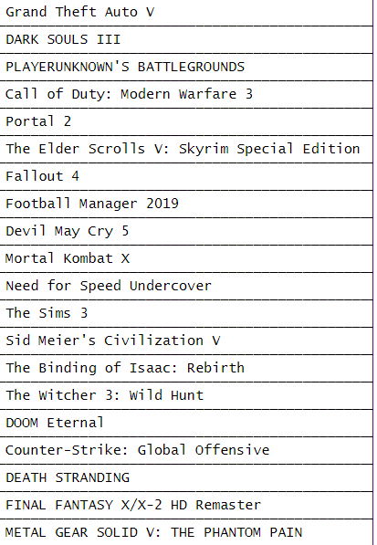

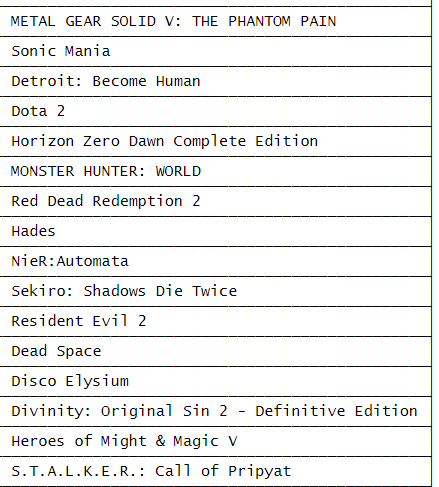

Мы постарались составить максимально обширный список на тот случай, чтобы любой пользователь мог получить наиболее точную рекомендацию по своим вкусам, а человек с небольшим игровым опытом смог оценить хотя бы несколько игр. Список игр не меняется, в каком-то роде он уже является решением проблемы холодного старта: мы считаем, что наш список наилучшим способом подходят для оценивания предпочтений пользователя, поскольку он включает в себя разнообразные, многомерные и в то же время известные игры, и даже у пользователя, который знаком с небольшим количеством игр, есть шанс попасть хотя бы на несколько игр, о которых он как минимум слышал.

Однако в том случае, если пользователь знает менее 10% игр из списка, ему лучше воспользоваться вторым сценарием, поскольку оцененных игр в первом может действительно оказаться недостаточно чтобы создать точную рекомендацию.

**5) Есть ли в этом сценарии вариант оценки “не знаю” - например, если пользователю выдало игру, в которую он не играл - можно ли просто пропустить ее оценку, не вводя команду stop? 6) не совсем понятно как учитывается игровой опыт во обоих сценариях. В первом при оценке игр стоит рассмотреть вариант ответа - не играл.**

*Ответ:* В первом сценарии была оценка “3”, которая интерпретировалась как “человек не знает, как оценить игру, или безразличен к ней”. В работе системы это значит, что игре присваивается вес тэга в единицу, т.е он не меняется и не влияет на рекомендацию. В случае когда игра оценивается на 5 или 4, то вес увеличивается в 2 и 1,5 раза; при оценке на 1 или 2, вес, соответственно, уменьшается. Существенно, если бы мы все-таки сразу прописали опцию “не играл”, то она бы тоже попала под оценку “3”, так как она никоим образом не влияет на дальнейшую рекомендацию. Поскольку пользователь действительно не мог пропустить игру в том случае, если он не был с ней знаком, и у него также не было возможности как-то заявить об этом, мы решили добавить к оценке “3” эту опцию. Спасибо за ценный комментарий!

Игровой опыт мы оценивали исключительно с перспективы понимает ли пользователь, игру с какими характеристики он желает увидеть. Мы предположили, что знание качеств желаемой игры можно ассоциировать с обладанием игрового опыта, а вот незнание скорее свойственно людям с малым или нулевым опытом. Однако это также правда, что и люди с большим опытом игр могут не знать, во что они хотели бы сыграть. Поэтому наше предположение всего лишь основано на личном опыте, и в целом однозначно сказать, что первым сценарием будут пользоваться только неопытные пользователи, а вторым — опытные, конечно, нельзя.

#### **Вопросы о работе второго сценария:**

**1) Во втором сценарии пользователю не очень понравится, если рекомендация будет выдавать те игры, в которые он уже играл**

*Ответ:* Если система порекомендовала пользователю уже знакомые игры, он действительно может остаться недовольным. Тем не менее, у пользователя есть возможность заменить такую рекомендацию, и он может менять ее до тех пор, пока не сможет получить рекомендацию на игру, в которую он еще не играл.

**2) В сценнарии с вводом текстового описания, как рекомендация реагирует на отрицания - например, пользователь вводит “Not MMORPG”**

*Ответ:* На такой запрос наш бот предложил нам следующие рекомендации:

1. World Of Leaders
2. Tkl Online Demo
3. Temtem
4. Guild Wars Trilogy
5. Hero Plus

Все из вышеперечисленных игр явлются MMORPG, сооответственно наш бот не реагирует на отрицания. Спасибо за указание на проблему, в дальнейшем постараемся исправить данный недочет!

#### **Общие вопросы о работе и создании системы:**

**1) Вопрос по поводу оценки системы: как пришли к оценке 80%, тестировщики оценивали все рекомендации в целом или каждую в отдельности (и если каждую в отдельности, то на каких из этапов сценариев)?**

*Ответ:* Каждый из разработчиков команды тестировал бот в среднем по 8-10 раз и записывал свои впечатления и комментарии для корректирования работы рекоменадетельной системы. Также пользование ботом было предложено нашим друзьям и знакомым. Оценка в 80% является общей, мы пришли к ней по итогам оценивания адекватности рекомендаций в целом для обоих сценариев, то есть.

**2) Единственное, пробовали ли вы реализовывать систему с помощью шайни? Я могу ошибаться, но я думала, что это обязательная часть проекта**

*Ответ:* Нет, не пробовали, т.к. изначально планировали работу системы в виде телеграмовского бота, во многом также и потому, что Шайни также не является обязательной частью проекта :) Шайни рассматривался лишь первое время и исключительно в качестве временной модели для работы над сценарием бота.

**3) в итоге не поняла, как запускать бота - архив распаковала, прочитала инструкцию - все пути в скрипте вроде бы итак локальные (ведут к той же папке, где скрипт лежит). Бот все равно никак не реагирует на команду /start.**

*Ответ:* При распаковке архива и прогоне всех строчек кода система работает, причем корректно. Это подтверждает тот факт, что в одном из комментариев об ожидаемом результате другой пользователь указал, что у него вышло запустить бот (дословно “Проверив это в боте я понял, что скорее всего нужно какое-то другое слово вместо good про plot, потому что редко кто так описывает свои игры, может быть thrilling”). Скорее всего, рецензент не прогнал последнюю строчку start_polling или же прогнал, но закрыл скрипт (поскольку нам не удалось положить бот на сервер, то в частности строчка start_polling должна быть в режиме обработки). В какой-то степени, это наша ошибка, потому что мы не указали эту особенность в инструкции к боту а также непосредственно в скрипте, и люди, не участвовавшие в разработке ботов, могли не быть в курсе этого. Мы обновили нашу инструкцию READ_ME и указали это свойство.

**4) Мне было бы интересно узнать, как бот будет реагировать на транслит(если такое не поддерживается, то лучше об этом написать!)**

*Ответ:* Такой запрос бот не поймет. Спасибо за предложение!

**5) Я русскоязычный пользователь. Хочется получить описание на русском**

*Ответ:* К сожалению, пока что такой возможности мы не предусмотрели, но в дальнейшем мы обязательно вернемся к этому!

**6) Будет ли приложение подходящим и полезным для новичков, кто только пытается начать играть, не имея игрового опыта до этого?**

*Ответ:* Да, поскольку в первый сценарий включены игры, о которых мог слышать даже не самый заинтересованный в них человек: например, серии The Sims, Call of Duty, GTA, Mortal Combat. То есть человек примерно может оценить, насколько он заинтересован в подобном жанре, в подобной стилистике и тематике в целом. Второй сценарий работы системы также может понравиться человеку в том случае, если он хорошо представляет себе, во что он хотел бы играть.

#### **Проверка примеров:**

[output not shown]

### **Чем вы гордитесь в своем приложении**

Мы очень довольны тем, что нам удалось реализовать рекомендательную систему с двумя рабочими сценариями в виде телеграм-бота при том, что никто из команды не был знаком с особенностями разработки и создания ботов. Мы также считаем, что главными достоинствами нашей системы является её универсальность и точность предсказаний.